# IODS final project

Milla Peltoniemi milla.peltoniemi@helsinki.fi

December 18, 2017

# Abstract

Analysing the exam points in statistics students dataset with the idea that the high exam points could be explained with gender, age and attitude.

[My github repository](https://github.com/nimirum/IODS-final)

# Introduction

The data is [a study](http://www.helsinki.fi/~kvehkala/JYTmooc/JYTOPKYS2-meta.txt) from a course “Johdatus yhteiskuntatilastotieteeseen, syksy 2014” about learning and teaching statistics. The data has been modified before analysis and the [data wrangling can be found here](https://github.com/nimirum/IODS-final/blob/master/learning2014.R). Data contains 183 individuals and it has 7 different variables

The data structure

```r
library(ggplot2);library(dplyr)
bluecolor <- "steelblue4"
lrn14 <- read.csv('learning2014.csv',sep=',')
str(lrn14)
```

```
## 'data.frame':    183 obs. of  7 variables:
##  $ gender  : Factor w/ 2 levels "F","M": 1 2 1 2 2 1 2 1 2 1 ...
##  $ age     : int  53 55 49 53 49 38 50 37 37 42 ...
##  $ deep    : num  3.75 2.88 3.88 3.5 3.75 ...
##  $ stra    : num  3.38 2.75 3.62 3.12 3.62 ...
##  $ surf    : num  2.58 3.17 2.25 2.25 2.83 ...
##  $ points  : int  25 12 24 10 22 21 21 31 24 26 ...
##  $ attitude: int  37 31 25 35 37 38 35 29 38 21 ...
```

At first I’ll take a look at the ages of the students. The most common age seems to be around 18-26 and the mean is about 26 and median is 22.

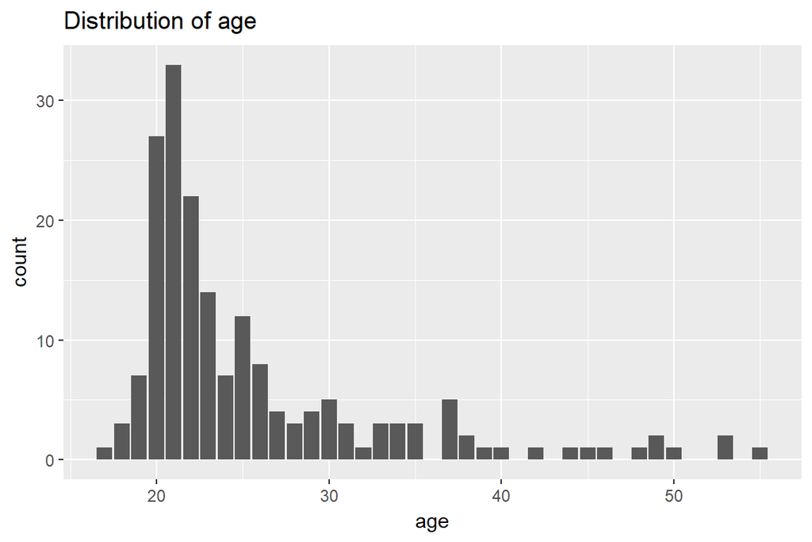

```r
g1 <- ggplot(lrn14, aes(x = age))
g1 + geom_bar() + ggtitle("Distribution of age")
```

```r
mean(lrn14$age)
```

```
## [1] 25.5847
```

```r
median(lrn14$age)
```

```
## [1] 22
```

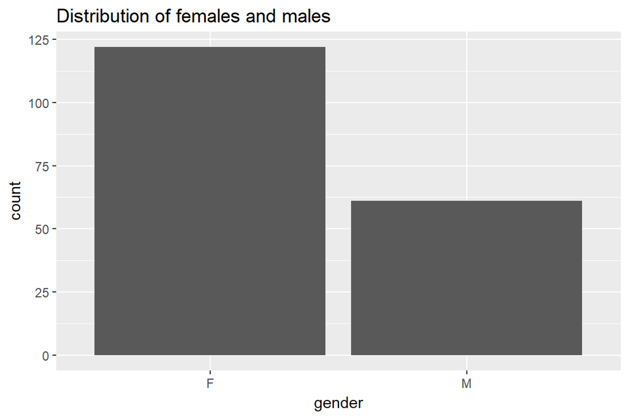

```r
g1 <- ggplot(lrn14, aes(x = gender))
g1 + geom_bar() + ggtitle("Distribution of females and males")
```

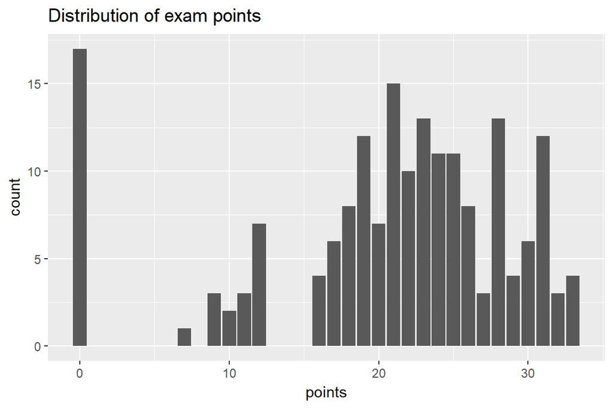

```r
g1 <- ggplot(lrn14, aes(x = points))
g1 + geom_bar() + ggtitle("Distribution of exam points")
```

I’m going to create binary variable for exam points that are the top 25% of the class. A look at the 4th quantile of the points shows that the limit for high points is 26 points. Therefore a student with points over 26 will have binary value TRUE in high_points from the exam.

```r
quantile(lrn14$points)
```

```
##   0%  25%  50%  75% 100%
##    0   18   22   26   33
```

```r
lrn14 <- mutate(lrn14, high_points = points >= 26)
```

Both genders have exam points that over the high_points limit (red dashed line).

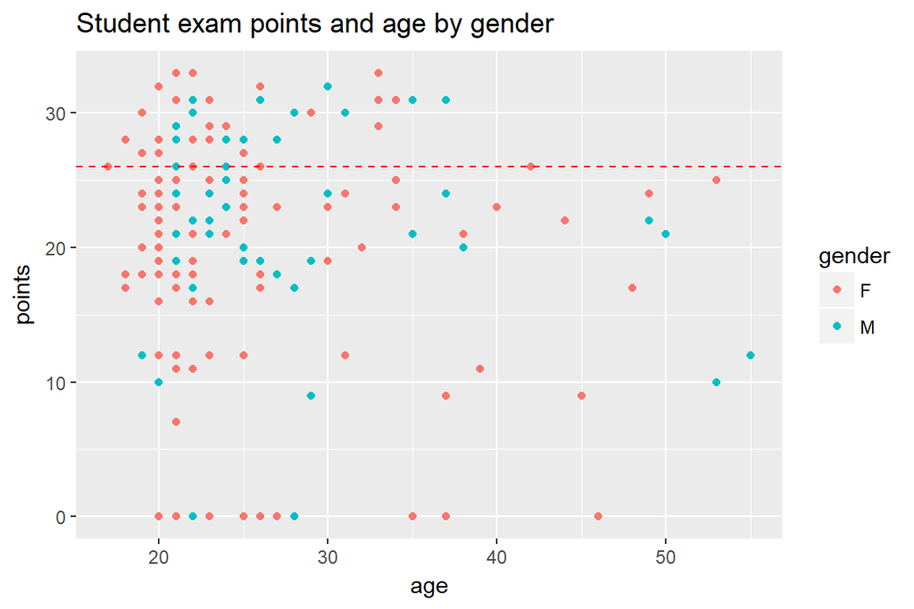

```r
g1 <- ggplot(lrn14, aes(x = age, y = points, col=gender)) + geom_point()
g1 + ggtitle("Student exam points and age by gender") + geom_hline(yintercept=26,linetype="dashed", color = "red")
```

I’ll also take a look at the age distibution between genders. Female students are younger on average than male students, which could originate from that men have to do a millitary service.

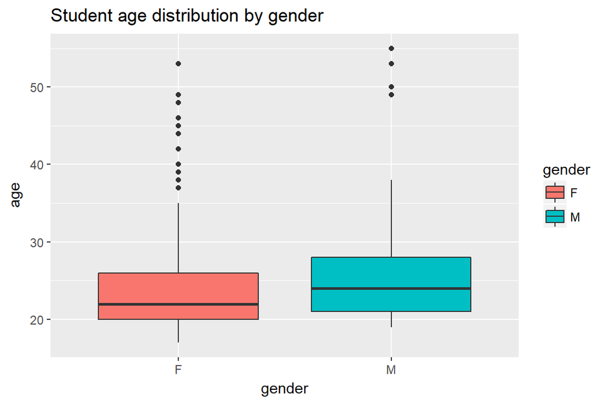

```r
g1 <- ggplot(lrn14, aes(x = gender, y = age, fill=gender))
g1 + geom_boxplot() + ggtitle("Student age distribution by gender")
```

There seems to be some correlation with attitude and gender.

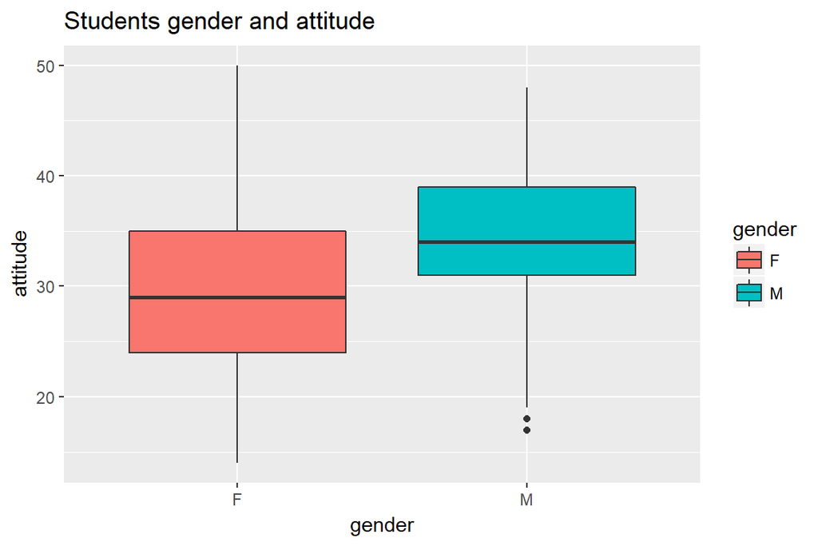

```r
g1 <- ggplot(lrn14, aes(x = gender, y = attitude, fill=gender))
g1 + geom_boxplot() + ggtitle("Students gender and attitude")
```

Correlation with gender and high points might be possible too, but only a little bit.

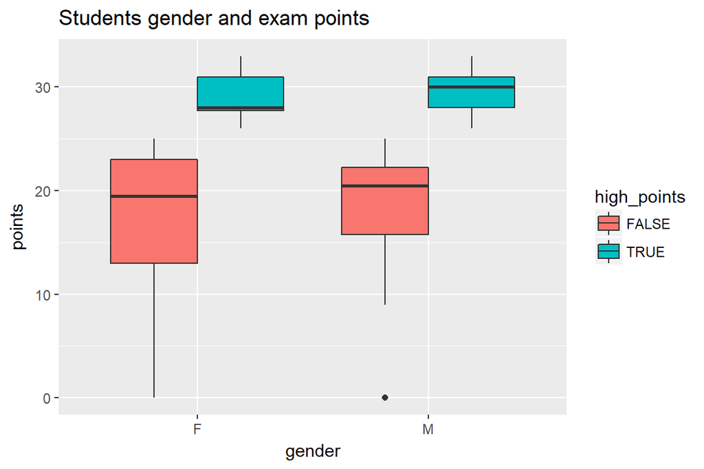

```r
g1 <- ggplot(lrn14, aes(x = gender, y = points, fill=high_points))
g1 + geom_boxplot() + ggtitle("Students gender and exam points")
```

# Logistic regression

Hypothesis: people with high points in exam have high attitude towards statistics

Hypothesis 2: age and gender is related to high points in exam

I’m going to test with logistic regression that are my hypotesis possible to predict from the data or not.

```r
model <- glm(high_points ~ gender+ attitude + age -1,  data = lrn14, family = "binomial")
summary(model)
```

```
##
## Call:
## glm(formula = high_points ~ gender + attitude + age - 1, family = "binomial",
##     data = lrn14)
##
## Deviance Residuals:
##     Min       1Q   Median       3Q      Max
## -1.7548  -0.8115  -0.5259   0.9753   2.4184
##
## Coefficients:
##          Estimate Std. Error z value Pr(>|z|)
## genderF  -4.91061    1.17115  -4.193 2.75e-05 ***
## genderM  -5.07099    1.29661  -3.911 9.19e-05 ***
## attitude  0.14182    0.03025   4.689 2.75e-06 ***
## age      -0.02173    0.02420  -0.898    0.369
## ---
## Signif. codes:  0 '***' 0.001 '**' 0.01 '*' 0.05 '.' 0.1 ' ' 1
##
## (Dispersion parameter for binomial family taken to be 1)
##
##     Null deviance: 253.69  on 183  degrees of freedom
## Residual deviance: 189.73  on 179  degrees of freedom
## AIC: 197.73
##
## Number of Fisher Scoring iterations: 4
```

```r
model <- glm(high_points ~ gender+ attitude -1,  data = lrn14, family = "binomial")
summary(model)
```

```
##
## Call:
## glm(formula = high_points ~ gender + attitude - 1, family = "binomial",
##     data = lrn14)
##
## Deviance Residuals:
##     Min       1Q   Median       3Q      Max
## -1.7227  -0.8120  -0.5257   0.9963   2.4884
##
## Coefficients:
##          Estimate Std. Error z value Pr(>|z|)
## genderF  -5.47308    1.00198  -5.462 4.70e-08 ***
## genderM  -5.67356    1.12403  -5.048 4.48e-07 ***
## attitude  0.14255    0.03018   4.723 2.32e-06 ***
## ---
## Signif. codes:  0 '***' 0.001 '**' 0.01 '*' 0.05 '.' 0.1 ' ' 1
##
## (Dispersion parameter for binomial family taken to be 1)
##
##     Null deviance: 253.69  on 183  degrees of freedom
## Residual deviance: 190.58  on 180  degrees of freedom
## AIC: 196.58
##
## Number of Fisher Scoring iterations: 4
```

```r
OR <- coef(model) %>% exp
CI <- confint(model) %>% exp
cbind(OR, CI)
```

```
##                   OR        2.5 %     97.5 %
## genderF  0.004198296 0.0005125748 0.02654966
## genderM  0.003435605 0.0003299406 0.02759490
## attitude 1.153207667 1.0902502780 1.22787713
```

```r
probabilities <- predict(model, type = "response")

hyp_test <- mutate(lrn14, probability = probabilities)
hyp_test <- mutate(hyp_test, prediction = probabilities > 0.5)
table(high_points = lrn14$high_points, prediction = probabilities > 0.5)
```

```
##            prediction
## high_points FALSE TRUE
##       FALSE   122    8
##       TRUE     35   18
```

```r
table(high_points = lrn14$high_points, prediction = hyp_test$prediction) %>% prop.table()  %>% addmargins()
```

```
##            prediction
## high_points      FALSE       TRUE        Sum
##       FALSE 0.66666667 0.04371585 0.71038251
##       TRUE  0.19125683 0.09836066 0.28961749
##       Sum   0.85792350 0.14207650 1.00000000
```

```r
loss_func <- function(class, prob) {
  n_wrong <- abs(class - prob) > 0.5
  mean(n_wrong)
}

loss_func(class = lrn14$high_points, prob = hyp_test$probability)
```

```
## [1] 0.2349727
```

The prediction model predicts about 23% of the predictions are wrong. This can be seen on the plot below. The accuracy is quite high because most of the values are predicted as FALSE. Predicing TRUE values was harder to get right.

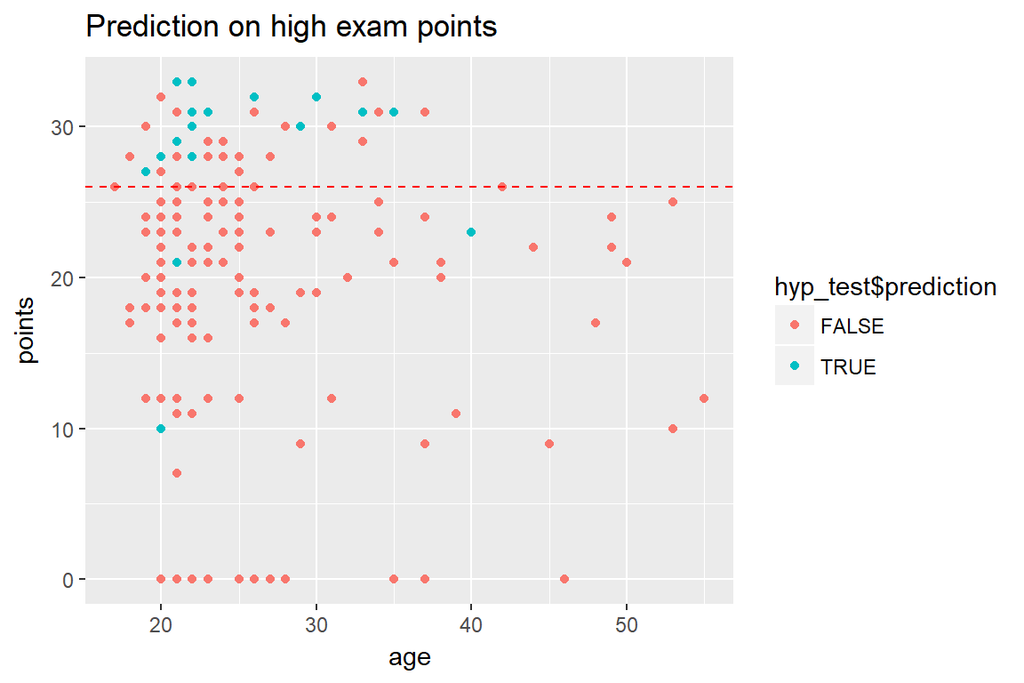

```r
g1 <- ggplot(lrn14, aes(x = age, y = points, col=hyp_test$prediction)) + geom_point()
g1 + ggtitle("Prediction on high exam points") + geom_hline(yintercept=26,linetype="dashed", color = "red")
```

# K-means

Let’s see can we cluster the student data and find some sub groups.

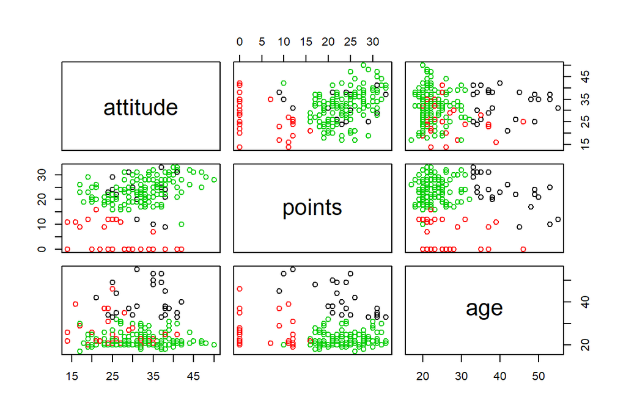

```r
sub_lrn14 <- select(lrn14, one_of(c("attitude","points","age")))
set.seed(-100055)
km <-kmeans(sub_lrn14[], centers = 3)
pairs(sub_lrn14, col = km$cluster)
```

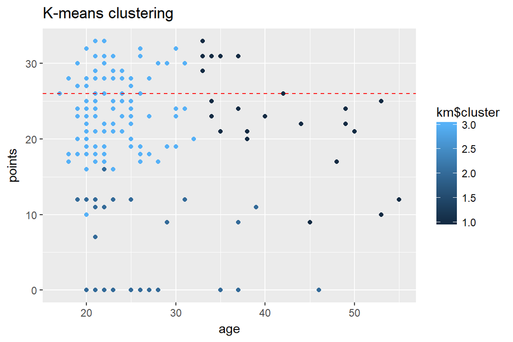

```r
g1 <- ggplot(lrn14, aes(x = age, y = points, col=km$cluster)) + geom_point()
g1 + ggtitle("K-means clustering") + geom_hline(yintercept=26,linetype="dashed", color = "red")
```

Clustering leads in a compact group of young stundet with some varinace in the exam points. It also clusters the failing students with really low exam points and distinctly older students from the average age.

# Conclusion

Second hypothesis about gender and age weren’t that relevant but they had some effect if the person got high points in exam. On the other hand the amount of females is a lot higher than males, which probably has an effect on the analysis.